# Documentation

Seyyedeh Zeinab Mousavi

8/21/2020

In this document, I aim to explain the process of generating simulated data via solving the Cole-Bendezú Model of Self-Regulation (CBMSR).

The main script for generating simulated childhood self-regulation processes is DataGeneration.R.

In the first lines of this script GridWare parameters are set:

```r
# GridWare project parameters:
GW_ProjectPath = "C:/PhD/Projects/SSG"
GW_ProjectName = "CBMSR"
GW_PR_binningThrlds <- c(0,1,2,3,4,5,19)
GW_EP_binningThrlds <- c(0,5,10,16)
GW_PRmax = 6
GW_EPmax = 3
```

The meaning of each parameter would become clear as we go on in this report.

The next step would be to determine model parameter distributions. We will later use these distributions to generate random candidates for model parameters. Here we adopt a uniform distribution for all parameters. This choice indicates that in this stage all we that we know about this parameters is their ranges.

```r
min_b_pr = 1; max_b_pr = 9
min_b_ep = 1; max_b_ep = 7

min_eta_pr = -0.5; max_eta_pr = -0.01
min_eta_ep = -0.5; max_eta_ep = -0.01

min_gamma1_pr = -0.5; max_gamma1_pr = 0.5
min_gamma1_ep = -0.5; max_gamma1_ep = 0.5

min_gamma2_pr = -0.1; max_gamma2_pr = 0.1
min_gamma2_ep = -0.1; max_gamma2_ep = 0.1

min_gamma3_pr = -0.5; max_gamma3_pr = 0.5
min_gamma3_ep = -0.5; max_gamma3_ep = 0.5
```

We then set the random seed, number of samples and initial values of the differential equations.

```r
# Setting random seed
set.seed(1)

# Number of samples in the simulated data set
Number_of_Samples = 2

# Initial values
state <- c(PR = 0.1,
           X1 = 0.1,
           EP = 0.1,
           X2 = 0.1)
```

Next, we use a loop to generated Number_of_samples simulated data. In each iteration of the loop a set of parameters is drawn from the uniform distributions specified above. The EP/PR equations are then solved using these parameters and the results are saved in the simulated data set.

```r
for (SampleIdx in 1:Number_of_Samples)
{
    ## Generating parameters by sampling from a uniform distribution
    R_b_ep = runif(n = 1, min = min_b_ep, max = max_b_ep)
    R_b_pr = runif(n = 1, min = min_b_pr, max = max_b_pr)

    R_eta_ep = runif(n = 1, min = min_eta_ep, max_eta_ep)
    R_eta_pr = runif(n = 1, min = min_eta_pr, max_eta_pr)

    R_gamma1_ep = runif(n = 1, min = min_gamma1_ep, max = max_gamma1_ep)
    R_gamma1_pr = runif(n = 1, min = min_gamma1_pr, max = max_gamma1_pr)

    R_gamma2_ep = runif(n = 1, min = min_gamma2_ep, max = max_gamma2_ep)
    R_gamma2_pr = runif(n = 1, min = min_gamma2_pr, max = max_gamma2_pr)

    R_gamma3_ep = runif(n = 1, min = min_gamma3_ep, max = max_gamma3_ep)
    R_gamma3_pr = runif(n = 1, min = min_gamma3_pr, max = max_gamma3_pr)

    ParameterList <- c(b_pr = R_b_pr,
                       b_ep = R_b_ep,
                       eta_pr = R_eta_pr,
                       eta_ep = R_eta_ep,
                       gamma1_pr = R_gamma1_pr,
                       gamma1_ep = R_gamma1_ep,
                       gamma2_pr = R_gamma2_pr,
                       gamma2_ep = R_gamma2_ep,
                       gamma3_pr = R_gamma3_pr,
                       gamma3_ep = R_gamma3_ep)

    ## Solving Cole-Bendezú Model of Self-Regulation (CBMSR)
    sol <- SolveCBMSR()


    ## Preparing the files required by GridWare

    # Updating GridWare project file to account for the newly
    # added trajectories
    UpdateProjectFile()

    # Converting the solutions of CBMSR
    # into trajectory files readable by GridWare
    PrepareTRJfile()


    ## Write data characteristics to file for future referencing
    WriteDataAttributesToFile()
}
```

The SolveCBMSR function solves the CBMSR using deSolve package:

```r
SolveCBMSR <- function(parameters, state,
                       timeLimit = 100,
                       NumSamples = 10000)
{
    library(deSolve)


    CBMSR <- function(t, state, parameters){
        with(as.list(c(state, parameters)),{

            dPR <- X1
            dX1 <- eta_pr*(PR - b_pr) + gamma1_pr*(EP - b_ep)
            + gamma2_pr*(PR - b_pr)*(EP - b_ep)
            + gamma3_pr*(EP - b_ep)*dPR
            dEP <- X2
            dX2 <- eta_ep*(EP - b_ep) + gamma1_ep*(PR - b_pr)
            + gamma2_ep*(PR - b_pr)*(EP - b_ep)
            + gamma3_ep*(PR - b_pr)*dEP

            list(c(dPR, dX1, dEP, dX2))

        })
    }


    times <- seq(0, timeLimit, length.out = NumSamples)

    sol <- ode(func = CBMSR, y = state,
                times = times, parms = parameters)

    library(ramify)
    sol[,c("PR")] = clip(x = sol[,c("PR")], .min = 0, .max = 18)
    sol[,c("EP")] = clip(x = sol[,c("EP")], .min = 0, .max = 15)

    return(sol)
}
```

The two coupled equations of CBMSR (equation 3 of the main document) are first written as four 1st order equations. These equations are then passed to ode function of deSolve package, along with the initial values and the time sequence. Next the results are clipped to be limited to the original study’s range ([0,18] for PR and [0,15] for EP).

The next step is to convert the model solutions provided by the SolveCBMSR function to GridWare-appropriate formats. This is done via UpdateProjectFile and PrepareTRJfile functions (available in R scripts with the same names in the project directory).

To run SSG method in GridWare, we require a project file (.gwf) describing the project properties and a set of trajectory file (.trj) containing the events and their onsets.

Here you can see the project file contents for two trajectory files:

```r
<GridWare>
<Config>
identifier  categorical person  C1  C2
state   integer prepotent responses 1   6   1   2   3   4   5   6
state   integer executive processes 1   3   1   2   3
MinReturns  2
MaxReturnTime   10
MaxReturnVisits 6
MinEventDuration    0
MinCellDuration 0
MissingValueSymbol  --
</Config>
<Trajectories>
person  Filename
C1  C1.trj
C2  C2.trj
</Trajectories>
</GridWare>
```

State variable *prepotent responses* is placed at x axis and state variable *executive processes* is placed at y axis. When new data is generated the name of the corresponding trajectory file (denoted as C + SampleIdx.trj) should be added to Trajectory section. The file names are also used as an identifier (person) which enables us to view each child’s trajectories separately in GridWare (more details later on).

The state variables in this project are defined as integers (the 4th and 5th lines in gwf file). The first two numbers are the minimum and maximum numbers each variable can have. The minimum number is always set to 1 and the maximum number is specified by GW_PRmax and GW_EPmax variables at the beginning of DataGeneration.R script.

The first lines of a trajectory file is displayed below:

```r
Onset   prepotent responses executive processes
2.440244    1   2
3.70037     1   3
3.860386    2   3
4.130413    3   3
4.350435    4   3
4.540454    5   3
4.70047     6   3
6.610661    6   2
```

Trajectory files are tab-delimited with .trj extension. The first column indicates the onset time of each event. The second and third columns are the states of PR and EP variables respectively. New events are added as new line whenever at least one of the variables changes.

The PrepareTRJfile function bins each data point in the solution obtained by SolveCBMSR function using GW_PR_binningThrlds and GW_EP_binningThrlds. Using .bincode function:

```r
# Assigning new categories to PR and EP
        PRbinNumber = .bincode(x = PR, breaks = GW_PR_binningThrlds,
                               right = FALSE, include.lowest = TRUE)
        EPbinNumber = .bincode(x = EP, breaks = GW_EP_binningThrlds,
                               right = FALSE, include.lowest = TRUE)
```

The two binning threshold vectors are specified at the beginning of DataGeneration.R script, which I repeat here:

```r
GW_PR_binningThrlds <- c(0,1,2,3,4,5,19)
GW_EP_binningThrlds <- c(0,5,10,16)
```

According to these thresholds and the specified inputs of the .bincode function (right = FALSE, include.lowest = TRUE), PR and EP solutions are reassigned as follows:

```r
For PR:
    [0,1)  -> 1
    [1,2)  -> 2
    [2,3)  -> 3
    [3,4)  -> 4
    [4,5)  -> 5
    [5,19) -> 6

For EP:
    [0,5)   -> 1
    [5,10)  -> 2
    [10,16) -> 3
```

Finally, the attributes of the current data, including model parameters, initial values and binning thresholds are written in DataAttributes.csv file (via WriteDataAttributesToFile function) for later referencing.

Here, I depict the solution for the second sample (PR in red and EP in blue):

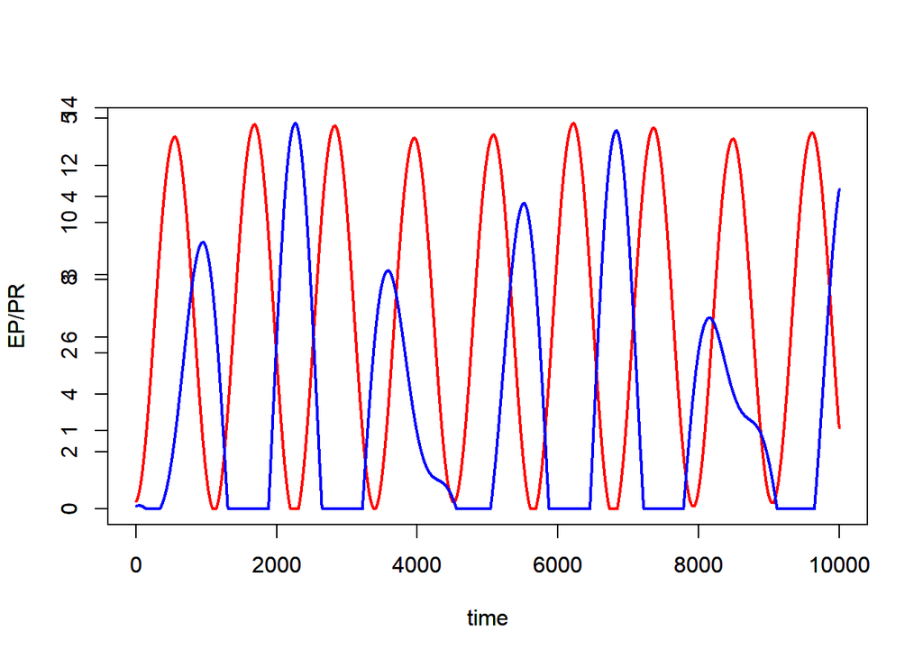

```r
plot(sol[,c("PR")], xlab = "time", ylab = "EP/PR", col="red",
     lwd=2, lty=1, type = "l")
par(new=TRUE)
plot(sol[,c("EP")], xlab = "time", ylab = "EP/PR", col="blue",
     lwd=2, lty=1, type = "l")
```

And the corresponding state space grid:

[figure not shown]